# Защита сервера с использованием Fail2ban

Лабораторная работа №16

Элсаиед Адел

Российский университет дружбы народов, Москва, Россия

7 января 2026

# Цель и задачи работы

## Цель лабораторной работы

Получение практических навыков настройки и использования программного средства Fail2ban для обеспечения базовой защиты сервера от атак типа brute force.

# Выполнение работы

## Контроль запуска Fail2ban

Выполнен мониторинг журнала Fail2ban для проверки корректности запуска сервиса и подключения к базе данных.

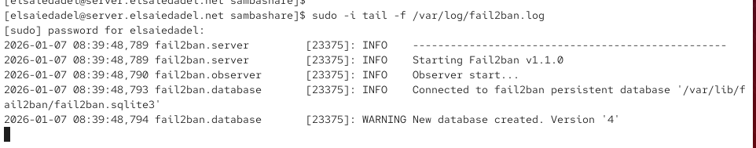

Просмотр журнала Fail2ban

## Локальная конфигурация Fail2ban

Создан файл локальной конфигурации `customisation.local`, используемый для задания пользовательских параметров защиты.

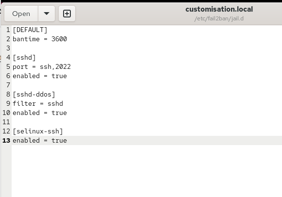

Файл customisation.local

## Применение конфигурации

После внесения изменений выполнен перезапуск Fail2ban.  
В журнале подтверждён запуск jail-модулей SSH.

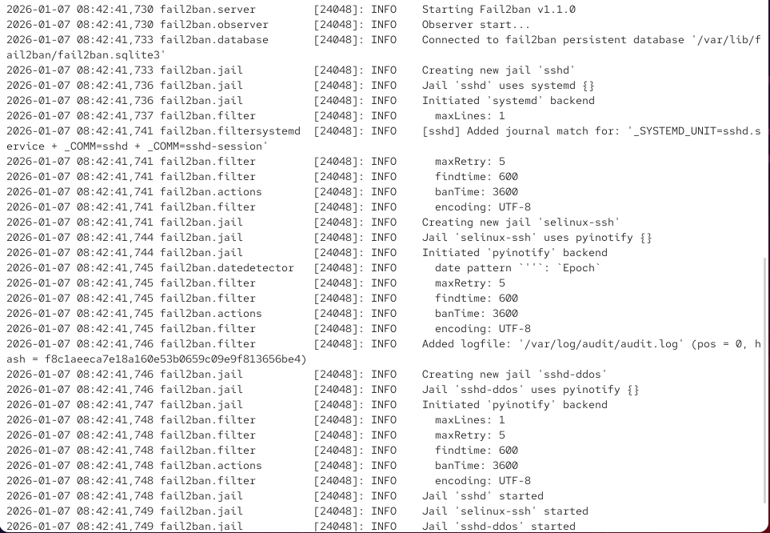

Журнал Fail2ban (SSH)

## Защита Apache

Включены модули защиты веб-сервера Apache: - защита от вредоносных ботов; - защита от атак Shellshock; - фильтрация подозрительных HTTP-запросов.

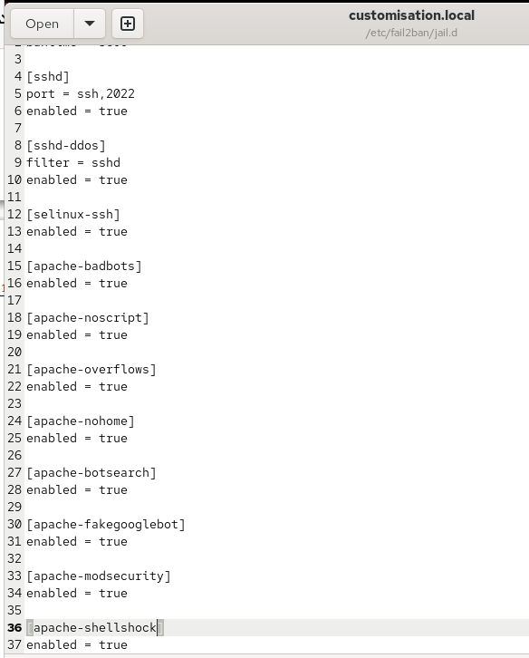

Настройка HTTP-защиты

## Проверка HTTP-защиты

После перезапуска Fail2ban в журнале зафиксирован запуск всех Apache jail-модулей.

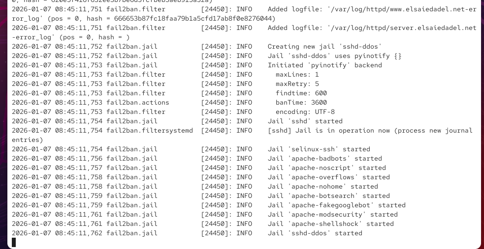

Журнал Fail2ban (HTTP)

## Настройка почты

Включена защита почтовых служб: - Postfix; - Postfix RBL; - Dovecot; - Postfix SASL.

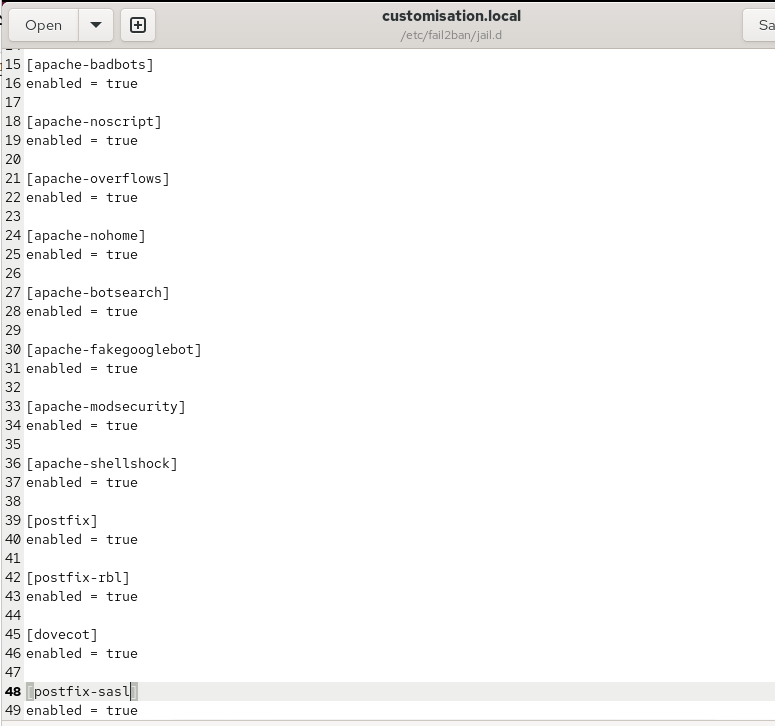

Настройка почтовых сервисов

## Применение настроек

После перезапуска Fail2ban подтверждён запуск jail-модулей почтовых сервисов.

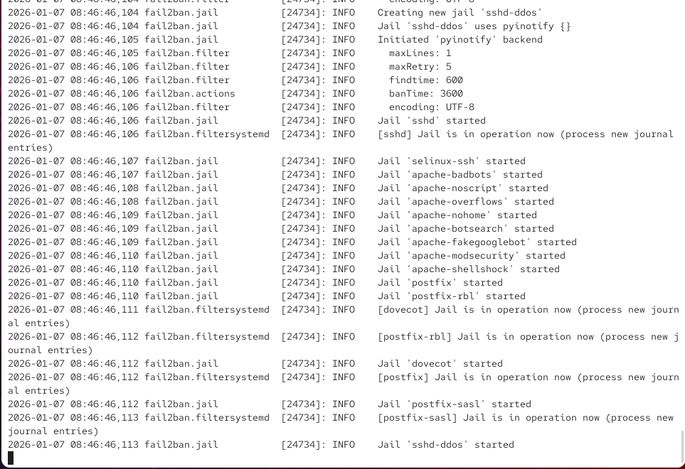

Журнал Fail2ban (Mail)

## Статус Fail2ban

Проверен общий статус Fail2ban и список активных jail-модулей.

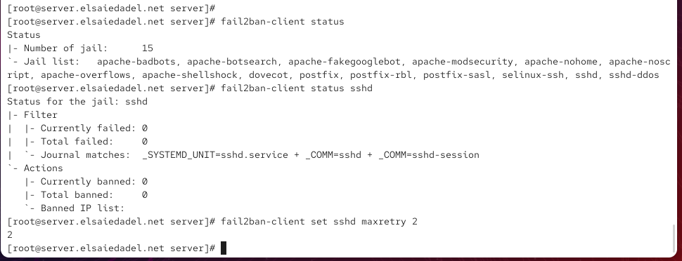

Статус Fail2ban

## Проверка блокировки SSH

Выполнена имитация атаки перебора пароля по SSH.  
Fail2ban успешно заблокировал IP-адрес клиента.

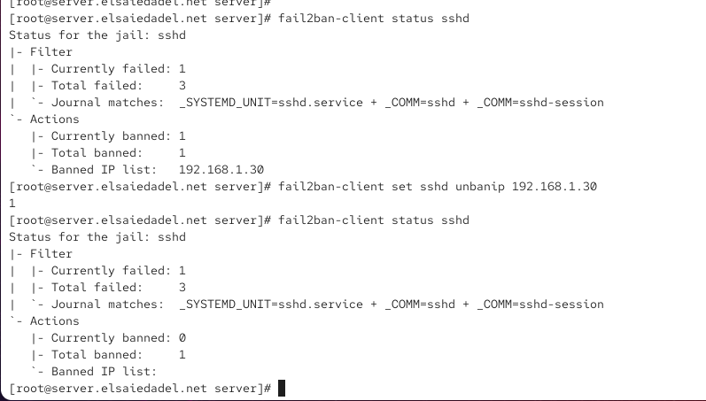

Блокировка IP-адреса

## Исключение доверенного IP

В конфигурации Fail2ban добавлен параметр `ignoreip` для исключения доверенного IP-адреса.

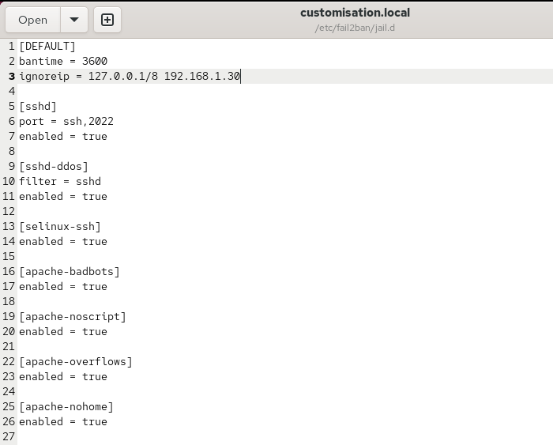

ignoreip в конфигурации

## Проверка ignoreip

Попытки входа с доверенного IP-адреса игнорируются Fail2ban, блокировка не применяется.

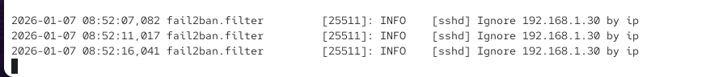

Журнал ignoreip

## Подготовка provisioning-скрипта

Создан каталог `protect` и размещены конфигурационные файлы Fail2ban для автоматической установки.

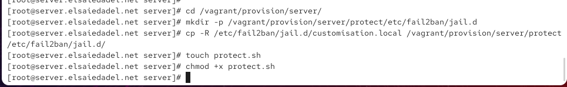

Каталог protect

## Скрипт protect.sh

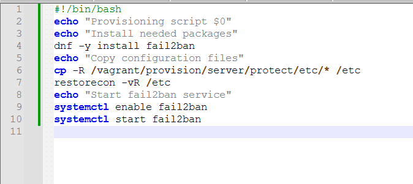

Скрипт protect.sh

# Выводы

## Вывод

В ходе лабораторной работы выполнена настройка Fail2ban для защиты SSH, HTTP и почтовых сервисов. Проведена проверка блокировки и разблокировки IP-адресов, реализовано исключение доверенных адресов и автоматизация конфигурации с использованием Vagrant. Полученные результаты подтверждают эффективность Fail2ban как средства базовой защиты сервера от атак типа brute force.